# ML_Assignment6

2023-02-28

### Load needed packages

```r
library(tidyverse)
library(rpart)
library(caret)
```

```r
library(rpart.plot)
library(pROC)
library(NHANES)
library(e1071)
```

### Load and check data

```r
# Load the NHANES dataset
data(NHANES)

# Subset the NHANES dataset to only include the 11 variables of interest
nhanes_data <- NHANES[, c("Age", "Race1", "Education", "HHIncome", "Weight", "Height", "Pulse", "Diabetes", "BMI", "PhysActive", "Smoke100")]

# View the first few rows of the subsetted data frame
head(nhanes_data)
```

```
## # A tibble: 6 × 11
##     Age Race1 Educat…¹ HHInc…² Weight Height Pulse Diabe…³   BMI PhysA…⁴ Smoke…⁵
##   <int> <fct> <fct>    <fct>    <dbl>  <dbl> <int> <fct>   <dbl> <fct>   <fct>
## 1    34 White High Sc… 25000-…   87.4   165.    70 No       32.2 No      Yes
## 2    34 White High Sc… 25000-…   87.4   165.    70 No       32.2 No      Yes
## 3    34 White High Sc… 25000-…   87.4   165.    70 No       32.2 No      Yes
## 4     4 Other <NA>     20000-…   17     105.    NA No       15.3 <NA>    <NA>
## 5    49 White Some Co… 35000-…   86.7   168.    86 No       30.6 No      Yes
## 6     9 White <NA>     75000-…   29.8   133.    82 No       16.8 <NA>    <NA>
## # … with abbreviated variable names ¹Education, ²HHIncome, ³Diabetes,
## #   ⁴PhysActive, ⁵Smoke100
```

```r
nhanes_data <- na.omit(nhanes_data)
```

### Partition data into training and testing

```r
set.seed(123)

train.indices<-createDataPartition(y=nhanes_data$Diabetes,p=0.7,list=FALSE)
training<-nhanes_data[train.indices,]
testing<-nhanes_data[-train.indices,]
```

```r
set.seed(123)
# Check the frequency of the outcome variable in the training dataset
table(training$Diabetes)
```

```
##
##   No  Yes
## 3988  462
```

```r
# Check the frequency of the outcome variable in the testing dataset
table(testing$Diabetes)
```

```
##
##   No  Yes
## 1709  197
```

### Model 1: Classification Trees

```r
set.seed(123)

#Creating 10-fold cross-validation
train_control_class<-trainControl(method="cv", number=10, sampling="down")

#Create sequence of cp parameters to try
grid.2 <- expand.grid(cp = seq(0.001, 0.01, by = 0.001))

#Train model
tree_model <-train(Diabetes ~ ., data = training, method="rpart",trControl=train_control_class, tuneGrid=grid.2)

tree_model$bestTune
```

```
##      cp
## 3 0.003
```

```r
tree_model
```

```
## CART
##
## 4450 samples
##   10 predictor
##    2 classes: 'No', 'Yes'
##
## No pre-processing
## Resampling: Cross-Validated (10 fold)
## Summary of sample sizes: 4005, 4005, 4004, 4005, 4005, 4006, ...
## Addtional sampling using down-sampling
##
## Resampling results across tuning parameters:
##
##   cp     Accuracy   Kappa
##   0.001  0.7044851  0.2225926
##   0.002  0.7042640  0.2271213
##   0.003  0.7056017  0.2274841
##   0.004  0.7042539  0.2287415
##   0.005  0.6907606  0.2210356
##   0.006  0.6972836  0.2227529
##   0.007  0.6932346  0.2189377
##   0.008  0.6930088  0.2193138
##   0.009  0.6885205  0.2180295
##   0.010  0.6887452  0.2174435
##
## Accuracy was used to select the optimal model using the largest value.
## The final value used for the model was cp = 0.003.
```

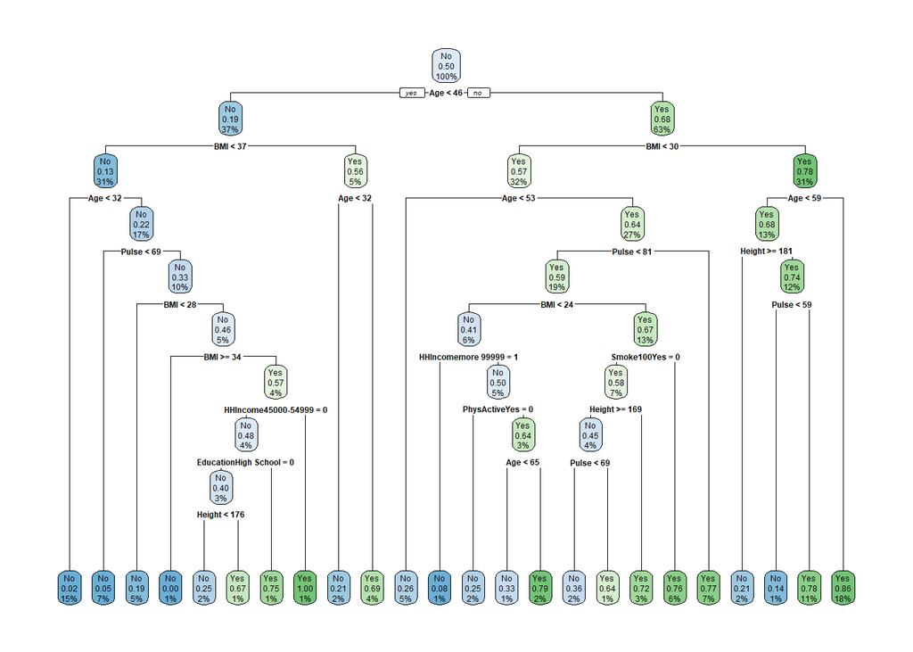

```r
rpart.plot(tree_model$finalModel)
```

```r
#Variable importance on the final model within training data
varImp(tree_model)
```

```
## rpart variable importance
##
##   only 20 most important variables shown (out of 32)
##
##                         Overall
## Age                    100.0000
## BMI                     69.1456
## Weight                  42.9851
## Pulse                   23.9010
## Height                  23.7335
## EducationCollege Grad   21.7327
## PhysActiveYes           11.1844
## HHIncomemore 99999      11.1066
## Race1Mexican             4.0257
## Race1White               3.8544
## HHIncome45000-54999      3.2644
## Smoke100Yes              2.6295
## HHIncome55000-64999      1.1927
## EducationHigh School     0.9177
## Race1Hispanic            0.9016
## EducationSome College    0.3512
## `HHIncome55000-64999`    0.0000
## `HHIncomemore 99999`     0.0000
## `EducationHigh School`   0.0000
## `HHIncome35000-44999`    0.0000
```

```r
#Accuracy metric and confusion matrix from training
confusionMatrix(tree_model)
```

```
## Cross-Validated (10 fold) Confusion Matrix
##
## (entries are percentual average cell counts across resamples)
##
##           Reference
## Prediction   No  Yes
##        No  62.6  2.4
##        Yes 27.0  8.0
##
##  Accuracy (average) : 0.7056
```

### Model 2: Logistic regression

```r
set.seed(123)

# Create 10-fold cross-validation
train_control_logistic <- trainControl(method = "cv", number = 10, sampling="down")

# Train logistic regression model
logistic_caret <- train(Diabetes ~ ., data = training, method = "glm", family = "binomial", trControl = train_control_logistic, preProcess = c("center", "scale"))

# Print the results
logistic_caret
```

```
## Generalized Linear Model
##
## 4450 samples
##   10 predictor
##    2 classes: 'No', 'Yes'
##
## Pre-processing: centered (26), scaled (26)
## Resampling: Cross-Validated (10 fold)
## Summary of sample sizes: 4005, 4005, 4004, 4005, 4005, 4006, ...
## Addtional sampling using down-sampling prior to pre-processing
##
## Resampling results:
##
##   Accuracy   Kappa
##   0.7148238  0.2362721
```

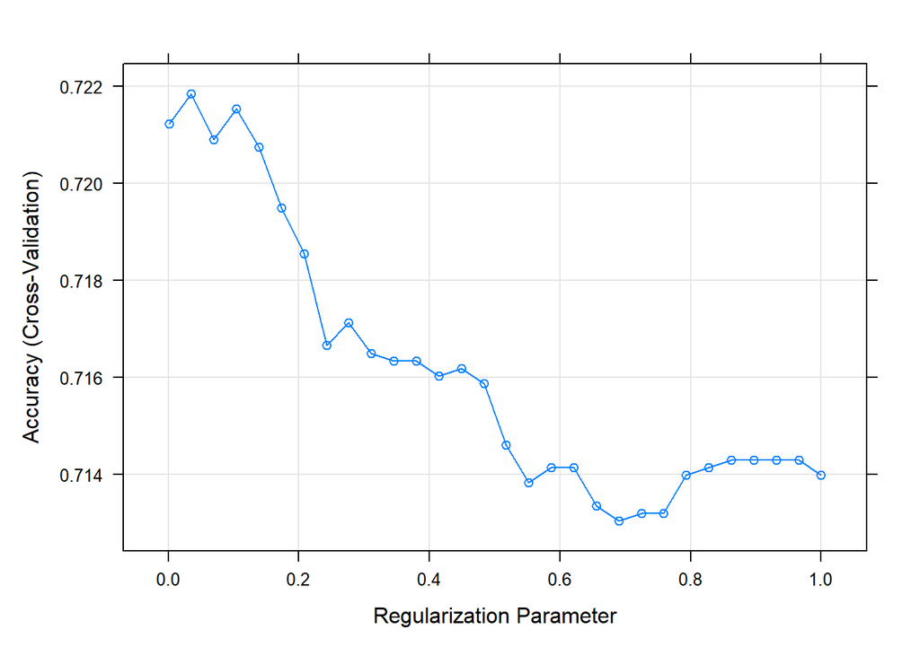

```r
# Incorporate different values for lambda
logistic_caret_2 <- train(Diabetes ~ ., data = nhanes_data, method = "glmnet", family = "binomial", trControl = train_control_logistic, preProcess = c("center", "scale"), tuneGrid = expand.grid(alpha = 0, lambda = seq(0.001, 1, length = 30)))


plot(logistic_caret_2)
```

```r
# Accuracy metric and confusion matrix from training
confusionMatrix(logistic_caret_2)
```

```
## Cross-Validated (10 fold) Confusion Matrix
##
## (entries are percentual average cell counts across resamples)
##
##           Reference
## Prediction   No  Yes
##        No  64.2  2.3
##        Yes 25.5  8.0
##
##  Accuracy (average) : 0.7218
```

### Model 3: Support Vector Classifiers

```r
modelLookup("svmLinear")
```

```
##       model parameter label forReg forClass probModel
## 1 svmLinear         C  Cost   TRUE     TRUE      TRUE
```

```r
set.seed(123)

#Set 10-fold cross-validation
train_control_svm<-trainControl(method="cv", number=10, sampling="down", classProbs = T)

#Train model
svm_caret<-train(Diabetes ~ ., data=training, method="svmLinear", trControl=train_control_svm, preProcess=c("center", "scale"))

svm_caret
```

```
## Support Vector Machines with Linear Kernel
##
## 4450 samples
##   10 predictor
##    2 classes: 'No', 'Yes'
##
## Pre-processing: centered (26), scaled (26)
## Resampling: Cross-Validated (10 fold)
## Summary of sample sizes: 4005, 4005, 4004, 4005, 4005, 4006, ...
## Addtional sampling using down-sampling prior to pre-processing
##
## Resampling results:
##
##   Accuracy  Kappa
##   0.711002  0.2333654
##
## Tuning parameter 'C' was held constant at a value of 1
```

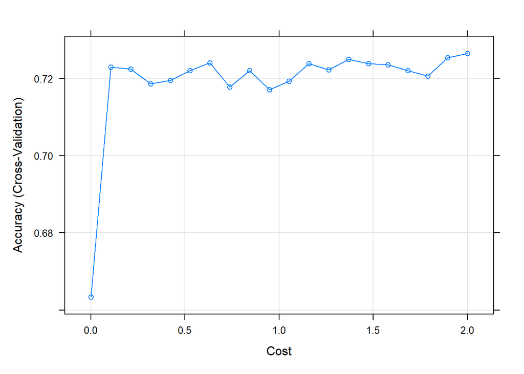

```r
# Train model
svm_model <- train(Diabetes ~ ., data = training, method = "svmLinear", trControl = train_control_svm,preProcess=c("center", "scale"), tuneGrid=expand.grid(C=seq(0.001,2, length=20)))

#Visualize accuracy versus values of C
plot(svm_model)
```

```r
#Obtain metrics of accuracy from training
confusionMatrix(svm_model)
```

```
## Cross-Validated (10 fold) Confusion Matrix
##
## (entries are percentual average cell counts across resamples)
##
##           Reference
## Prediction   No  Yes
##        No  64.6  2.3
##        Yes 25.1  8.1
##
##  Accuracy (average) : 0.7265
```

### Select a “optimal” model and calculate final evaluation metrics in the test set

After comparing the average accuracy among three different models, Support Vector Classifiers has the highest average accuracy with a better performance.

```r
set.seed(123)
#Make predictions in testset
svm_model_pred<-predict(svm_model, testing)

#Get evaluation metrics from test set
confusionMatrix(svm_model_pred, testing$Diabetes, positive="Yes")
```

```
## Confusion Matrix and Statistics
##
##           Reference
## Prediction   No  Yes
##        No  1192   34
##        Yes  517  163
##
##                Accuracy : 0.7109
##                  95% CI : (0.69, 0.7312)
##     No Information Rate : 0.8966
##     P-Value [Acc > NIR] : 1
##
##                   Kappa : 0.2518
##
##  Mcnemar's Test P-Value : <2e-16
##
##             Sensitivity : 0.82741
##             Specificity : 0.69748
##          Pos Pred Value : 0.23971
##          Neg Pred Value : 0.97227
##              Prevalence : 0.10336
##          Detection Rate : 0.08552
##    Detection Prevalence : 0.35677
##       Balanced Accuracy : 0.76245
##
##        'Positive' Class : Yes
##
```

```r
#Create ROC Curve for Analysis
pred_prob<-predict(svm_model, testing, type="prob")
```

[output not shown]

#### *List and describe at least two limitations/considerations of the model generated by this analysis. Limitations can be analytical or they can be considerations that need to be made regarding how the model would be applied in practice.*

Comments:

1. Generalizability: These models were developed using a specific dataset (NHANES) and may not necessarily generalize to other populations or settings. It’s important to validate the model on external datasets to ensure that it can perform well in different contexts.

Check the frequency of the outcome variable in the training dataset

`Diabetes`  
No (3988) Yes (462)

Check the frequency of the outcome variable in the testing dataset

`Diabetes`  
No (1709) Yes (197)

2. Imbalanced classes: The Diabetes variable in the cleaning dataset is imbalanced, with only 10.4% of observations being positive cases. This can lead to biased model performance, where the model is more accurate at predicting the majority class (no diabetes) and less accurate at predicting the minority class (diabetes). This is especially important to consider in practice, where the costs of false negatives (not detecting diabetes in a patient who has it) can be high. It may be necessary to balance the classes or use different performance metrics that take into account the imbalanced nature of the data.